# glmers for reversal

Sophie Paolizzi

4/4/2022

### Base model

Start with the basics…. should be an effect of trial number based on tidy_markdown.

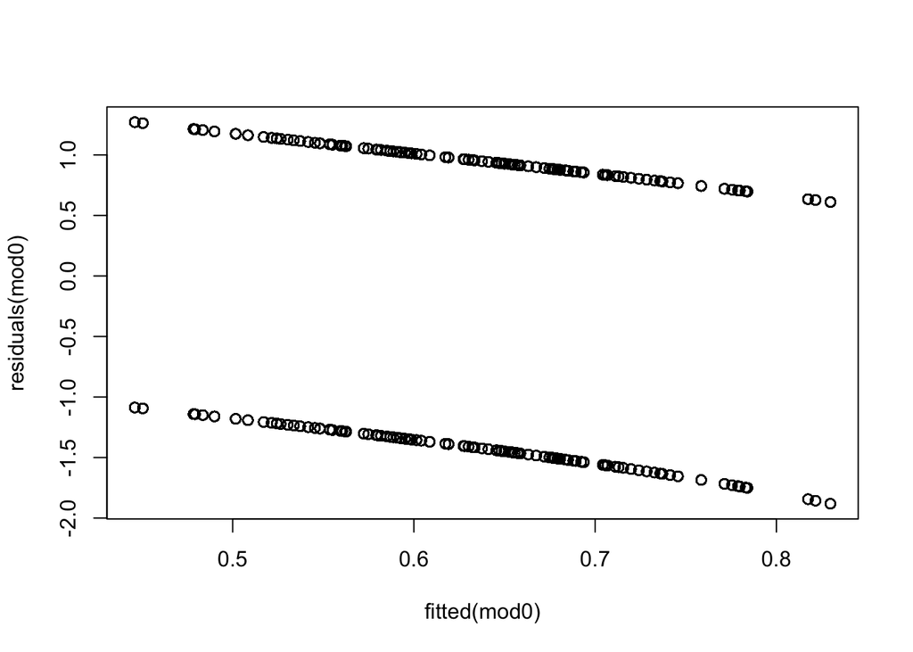

```r
minfo[["mod0"]] <- c(fixed="Intercept", l2="Intercept/Subject")
mod0 <- glmer(ResponseCorrect_num ~ 1 + (1|subject), family = binomial, control = glmerControl(optimizer = "bobyqa"),
    nAGQ = 10, data = df)
plot(fitted(mod0), residuals(mod0))
```

```r
minfo[["mod1"]] <- c(fixed="Total Trial", l2="Intercept/Subject")
mod1 <- glmer(ResponseCorrect_num ~  total_trialnum + (1|subject), data = df, family = binomial, control = glmerControl(optimizer = "bobyqa"),
    nAGQ = 10); summary(mod1)
```

```
## Generalized linear mixed model fit by maximum likelihood (Adaptive
##   Gauss-Hermite Quadrature, nAGQ = 10) [glmerMod]
##  Family: binomial  ( logit )
## Formula: ResponseCorrect_num ~ total_trialnum + (1 | subject)
##    Data: df
## Control: glmerControl(optimizer = "bobyqa")
##
##      AIC      BIC   logLik deviance df.resid
##  34628.6  34653.2 -17311.3  34622.6    27114
##
## Scaled residuals:
##     Min      1Q  Median      3Q     Max
## -2.2473 -1.1626  0.6245  0.7457  1.1344
##
## Random effects:
##  Groups  Name        Variance Std.Dev.
##  subject (Intercept) 0.1602   0.4003
## Number of obs: 27117, groups:  subject, 137
##
## Fixed effects:
##                  Estimate Std. Error z value Pr(>|z|)
## (Intercept)     0.6595314  0.0429691  15.349   <2e-16 ***
## total_trialnum -0.0004527  0.0002235  -2.026   0.0428 *
## ---
## Signif. codes:  0 '***' 0.001 '**' 0.01 '*' 0.05 '.' 0.1 ' ' 1
##
## Correlation of Fixed Effects:
##             (Intr)
## total_trlnm -0.524
## optimizer (bobyqa) convergence code: 0 (OK)
## Model failed to converge with max|grad| = 0.0571438 (tol = 0.002, component 1)
## Model is nearly unidentifiable: very large eigenvalue
##  - Rescale variables?
```

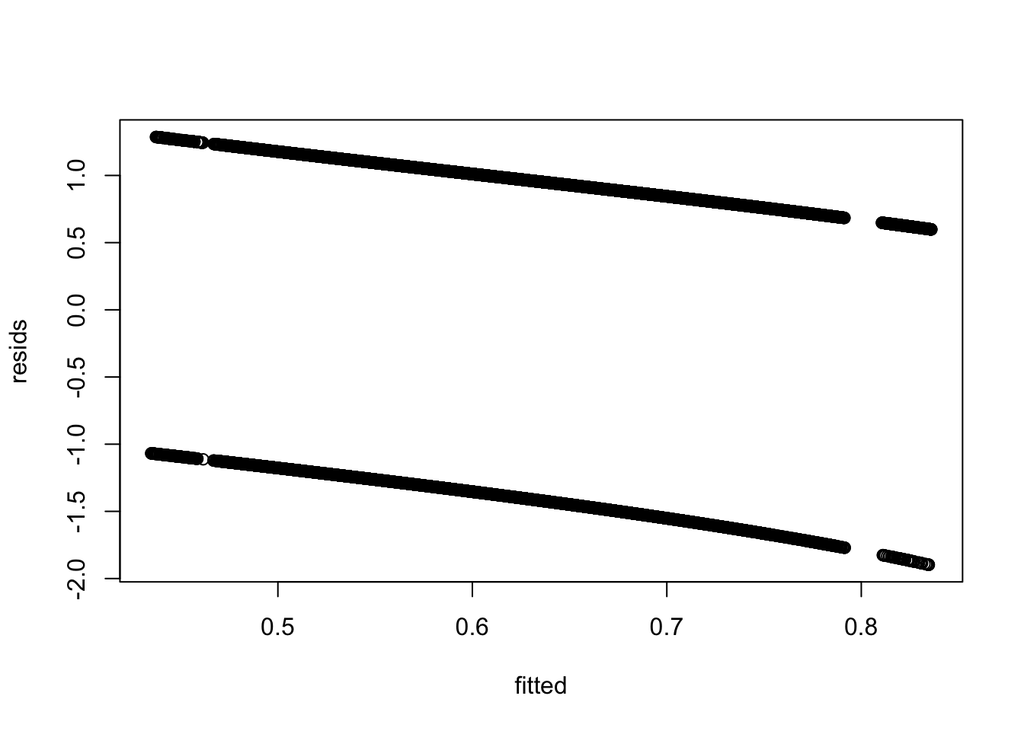

```r
resids <- residuals(mod1)
fitted <- fitted(mod1)
plot(fitted, resids)
```

```r
#note: trial_number is within-block (i.e., 1-40)
minfo[["mod1.1"]] <- c(fixed="block_trial_number, block number", l2="Intercept/Subject")
mod1.1 <- glmer(ResponseCorrect_num ~  trial_number + block_number + (1|subject), data = df, family = binomial, control = glmerControl(optimizer = "bobyqa"),
    nAGQ = 10); summary(mod1.1)
```

```
## Generalized linear mixed model fit by maximum likelihood (Adaptive
##   Gauss-Hermite Quadrature, nAGQ = 10) [glmerMod]
##  Family: binomial  ( logit )
## Formula: ResponseCorrect_num ~ trial_number + block_number + (1 | subject)
##    Data: df
## Control: glmerControl(optimizer = "bobyqa")
##
##      AIC      BIC   logLik deviance df.resid
##  34630.3  34663.1 -17311.2  34622.3    27113
##
## Scaled residuals:
##     Min      1Q  Median      3Q     Max
## -2.2528 -1.1633  0.6241  0.7465  1.1378
##
## Random effects:
##  Groups  Name        Variance Std.Dev.
##  subject (Intercept) 0.1604   0.4005
## Number of obs: 27117, groups:  subject, 137
##
## Fixed effects:
##                Estimate Std. Error z value Pr(>|z|)
## (Intercept)   0.6718467  0.0512029  13.121   <2e-16 ***
## trial_number  0.0001274  0.0011199   0.114   0.9094
## block_number -0.0194119  0.0091221  -2.128   0.0333 *
## ---
## Signif. codes:  0 '***' 0.001 '**' 0.01 '*' 0.05 '.' 0.1 ' ' 1
##
## Correlation of Fixed Effects:
##             (Intr) trl_nm
## trial_numbr -0.449
## block_numbr -0.536  0.001
## optimizer (bobyqa) convergence code: 0 (OK)
## Model is nearly unidentifiable: very large eigenvalue
##  - Rescale variables?
```

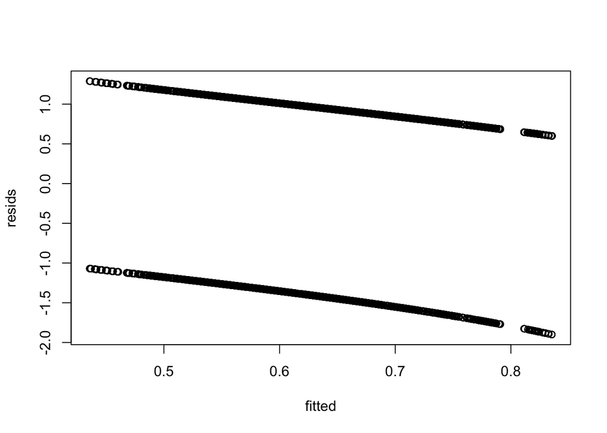

```r
resids <- residuals(mod1.1)
fitted <- fitted(mod1.1)
plot(fitted, resids)
```

### Rescale trials

Carry 2.1 forward, total_trial covers what we need best. Z-scoring seems appropriate.

```r
minfo[["mod2"]] <- c(fixed="block_trial_z, block number", l2="Intercept/Subject")
mod2 <- glmer(ResponseCorrect_num ~ trial_z + block_number + (1 |subject), data = df, family = binomial, control = glmerControl(optimizer = "bobyqa"),
    nAGQ = 10); summary(mod2)
```

```
## Generalized linear mixed model fit by maximum likelihood (Adaptive
##   Gauss-Hermite Quadrature, nAGQ = 10) [glmerMod]
##  Family: binomial  ( logit )
## Formula: ResponseCorrect_num ~ trial_z + block_number + (1 | subject)
##    Data: df
## Control: glmerControl(optimizer = "bobyqa")
##
##      AIC      BIC   logLik deviance df.resid
##  34630.3  34663.1 -17311.2  34622.3    27113
##
## Scaled residuals:
##     Min      1Q  Median      3Q     Max
## -2.2528 -1.1633  0.6241  0.7465  1.1378
##
## Random effects:
##  Groups  Name        Variance Std.Dev.
##  subject (Intercept) 0.1604   0.4005
## Number of obs: 27117, groups:  subject, 137
##
## Fixed effects:
##               Estimate Std. Error z value Pr(>|z|)
## (Intercept)   0.674465   0.045751  14.742   <2e-16 ***
## trial_z       0.001468   0.012917   0.114   0.9095
## block_number -0.019413   0.009122  -2.128   0.0333 *
## ---
## Signif. codes:  0 '***' 0.001 '**' 0.01 '*' 0.05 '.' 0.1 ' ' 1
##
## Correlation of Fixed Effects:
##             (Intr) tril_z
## trial_z      0.000
## block_numbr -0.600  0.001
```

```r
minfo[["mod2.1"]] <- c(fixed="total_trial_z", l2="Intercept/Subject")
mod2.1 <- glmer(ResponseCorrect_num ~ total_trial_z + (1 |subject), data = df, family = binomial, control = glmerControl(optimizer = "bobyqa"),
    nAGQ = 10)
```

### Add in previous RT

Big effect here; also seems trial-wise RT isn’t doing much: might leave it in for a bit longer in case there are interesting interactive effects later.

```r
minfo[["mod3"]] <- c(fixed="total_trial_z, PrevRT", l2="Intercept/Subject")
mod3 <- glmer(ResponseCorrect_num ~ total_trial_z + prevRT_log + (1 |subject), data = df, family = binomial, control = glmerControl(optimizer = "bobyqa"))
summary(mod3)
```

```
## Generalized linear mixed model fit by maximum likelihood (Laplace
##   Approximation) [glmerMod]
##  Family: binomial  ( logit )
## Formula: ResponseCorrect_num ~ total_trial_z + prevRT_log + (1 | subject)
##    Data: df
## Control: glmerControl(optimizer = "bobyqa")
##
##      AIC      BIC   logLik deviance df.resid
##  34616.1  34648.9 -17304.1  34608.1    27112
##
## Scaled residuals:
##     Min      1Q  Median      3Q     Max
## -2.2995 -1.1618  0.6249  0.7445  1.3447
##
## Random effects:
##  Groups  Name        Variance Std.Dev.
##  subject (Intercept) 0.1456   0.3816
## Number of obs: 27116, groups:  subject, 137
##
## Fixed effects:
##               Estimate Std. Error z value Pr(>|z|)
## (Intercept)    0.06120    0.15169   0.403  0.68661
## total_trial_z -0.01808    0.01311  -1.379  0.16782
## prevRT_log     0.09416    0.02504   3.760  0.00017 ***
## ---
## Signif. codes:  0 '***' 0.001 '**' 0.01 '*' 0.05 '.' 0.1 ' ' 1
##
## Correlation of Fixed Effects:
##             (Intr) ttl_t_
## total_trl_z -0.167
## prevRT_log  -0.973  0.171
```

```r
minfo[["mod3.1"]] <- c(fixed="total_trial_z, PrevRT, RT", l2="Intercept/Subject")
mod3.1 <- glmer(ResponseCorrect_num ~ total_trial_z + prevRT_log + rt_log + (1 |subject), data = df, family = binomial, control = glmerControl(optimizer = "bobyqa"))
summary(mod3.1)
```

```
## Generalized linear mixed model fit by maximum likelihood (Laplace
##   Approximation) [glmerMod]
##  Family: binomial  ( logit )
## Formula: ResponseCorrect_num ~ total_trial_z + prevRT_log + rt_log + (1 |
##     subject)
##    Data: df
## Control: glmerControl(optimizer = "bobyqa")
##
##      AIC      BIC   logLik deviance df.resid
##  34617.1  34658.2 -17303.6  34607.1    27111
##
## Scaled residuals:
##     Min      1Q  Median      3Q     Max
## -2.2944 -1.1618  0.6249  0.7444  1.3368
##
## Random effects:
##  Groups  Name        Variance Std.Dev.
##  subject (Intercept) 0.1433   0.3785
## Number of obs: 27116, groups:  subject, 137
##
## Fixed effects:
##               Estimate Std. Error z value Pr(>|z|)
## (Intercept)   -0.04429    0.18458  -0.240   0.8104
## total_trial_z -0.01644    0.01321  -1.245   0.2132
## prevRT_log     0.08563    0.02643   3.239   0.0012 **
## rt_log         0.02643    0.02654   0.996   0.3194
## ---
## Signif. codes:  0 '***' 0.001 '**' 0.01 '*' 0.05 '.' 0.1 ' ' 1
##
## Correlation of Fixed Effects:
##             (Intr) ttl_t_ prvRT_
## total_trl_z -0.207
## prevRT_log  -0.568  0.120
## rt_log      -0.573  0.124 -0.326
```

```r
car::vif(mod3.1)
```

```
## total_trial_z    prevRT_log        rt_log
##      1.046234      1.152356      1.153463
```

```r
dependlab::render_flex_aictab(minfo=minfo, mod0, mod1, mod1.1, mod2, mod2.1, mod3, mod3.1) %>% autofit()
```

| model | fixed | l2 | logLik | AIC | 𝚫AIC | df | weight |
| --- | --- | --- | --- | --- | --- | --- | --- |
| mod0 | Intercept | Intercept/Subject | -17,313.42 | 34,630.85 | 14.732219 | 2 | 0.000 |
| mod1 | Total Trial | Intercept/Subject | -17,311.30 | 34,628.59 | 12.482017 | 3 | 0.001 |
| mod1.1 | block_trial_number, block number | Intercept/Subject | -17,311.15 | 34,630.30 | 14.189598 | 4 | 0.001 |
| mod2 | block_trial_z, block number | Intercept/Subject | -17,311.15 | 34,630.30 | 14.189598 | 4 | 0.001 |
| mod2.1 | total_trial_z | Intercept/Subject | -17,311.29 | 34,628.59 | 12.477013 | 3 | 0.001 |
| mod3 | total_trial_z, PrevRT | Intercept/Subject | -17,304.06 | 34,616.11 | 0.000000 | 4 | 0.621 |
| mod3.1 | total_trial_z, PrevRT, RT | Intercept/Subject | -17,303.56 | 34,617.12 | 1.010003 | 5 | 0.375 |

### Task_phase

Some clear improvement! Good news for our hypotheses re: task phase shifts

```r
minfo[["mod4"]] <- c(fixed="total_trial_z, PrevRT, task phase", l2="Intercept/Subject")
mod4 <- glmer(ResponseCorrect_num ~ total_trial_z + prevRT_log + rt_log + task_phase + (1 |subject), data = df, family = binomial, control = glmerControl(optimizer = "bobyqa"))
summary(mod4)
```

```
## Generalized linear mixed model fit by maximum likelihood (Laplace
##   Approximation) [glmerMod]
##  Family: binomial  ( logit )
## Formula:
## ResponseCorrect_num ~ total_trial_z + prevRT_log + rt_log + task_phase +
##     (1 | subject)
##    Data: df
## Control: glmerControl(optimizer = "bobyqa")
##
##      AIC      BIC   logLik deviance df.resid
##  34444.8  34494.0 -17216.4  34432.8    27110
##
## Scaled residuals:
##     Min      1Q  Median      3Q     Max
## -2.4637 -1.1460  0.6108  0.7526  1.2853
##
## Random effects:
##  Groups  Name        Variance Std.Dev.
##  subject (Intercept) 0.1487   0.3856
## Number of obs: 27116, groups:  subject, 137
##
## Fixed effects:
##                     Estimate Std. Error z value Pr(>|z|)
## (Intercept)         0.330292   0.188592   1.751  0.07988 .
## total_trial_z       0.007025   0.013375   0.525  0.59942
## prevRT_log          0.070710   0.026633   2.655  0.00793 **
## rt_log              0.008174   0.026756   0.306  0.75997
## task_phaseReversal -0.348110   0.026418 -13.177  < 2e-16 ***
## ---
## Signif. codes:  0 '***' 0.001 '**' 0.01 '*' 0.05 '.' 0.1 ' ' 1
##
## Correlation of Fixed Effects:
##             (Intr) ttl_t_ prvRT_ rt_log
## total_trl_z -0.183
## prevRT_log  -0.568  0.114
## rt_log      -0.575  0.116 -0.319
## tsk_phsRvrs -0.153 -0.133  0.042  0.053
```

```r
dependlab::render_flex_aictab(minfo=minfo, mod0, mod1, mod1.1, mod2, mod2.1, mod3, mod3.1, mod4) %>% autofit()
```

| model | fixed | l2 | logLik | AIC | 𝚫AIC | df | weight |
| --- | --- | --- | --- | --- | --- | --- | --- |
| mod0 | Intercept | Intercept/Subject | -17,313.42 | 34,630.85 | 186.0745 | 2 | 0 |
| mod1 | Total Trial | Intercept/Subject | -17,311.30 | 34,628.59 | 183.8243 | 3 | 0 |
| mod1.1 | block_trial_number, block number | Intercept/Subject | -17,311.15 | 34,630.30 | 185.5318 | 4 | 0 |
| mod2 | block_trial_z, block number | Intercept/Subject | -17,311.15 | 34,630.30 | 185.5318 | 4 | 0 |
| mod2.1 | total_trial_z | Intercept/Subject | -17,311.29 | 34,628.59 | 183.8193 | 3 | 0 |
| mod3 | total_trial_z, PrevRT | Intercept/Subject | -17,304.06 | 34,616.11 | 171.3423 | 4 | 0 |
| mod3.1 | total_trial_z, PrevRT, RT | Intercept/Subject | -17,303.56 | 34,617.12 | 172.3523 | 5 | 0 |
| mod4 | total_trial_z, PrevRT, task phase | Intercept/Subject | -17,216.39 | 34,444.77 | 0.0000 | 6 | 1 |

### previous feedback (previous error, kind of)

A previous percieved error leads to chooising the wrong stimulus on the current trial. Seems like a basic win-stay lose-switch strategy, but ignoring the probabilistic part.

```r
minfo[["mod5"]] <- c(fixed="total_trial_z, PrevRT, task phase, previous feedback", l2="Intercept/Subject")
mod5 <- glmer(ResponseCorrect_num ~ total_trial_z + prevRT_log + rt_log + task_phase + prevFeedback + (1 |subject), data = df, family = binomial, control = glmerControl(optimizer = "bobyqa"))
summary(mod5)
```

```
## Generalized linear mixed model fit by maximum likelihood (Laplace
##   Approximation) [glmerMod]
##  Family: binomial  ( logit )
## Formula:
## ResponseCorrect_num ~ total_trial_z + prevRT_log + rt_log + task_phase +
##     prevFeedback + (1 | subject)
##    Data: df
## Control: glmerControl(optimizer = "bobyqa")
##
##      AIC      BIC   logLik deviance df.resid
##  33613.6  33671.1 -16799.8  33599.6    27109
##
## Scaled residuals:
##     Min      1Q  Median      3Q     Max
## -2.8442 -1.0682  0.5459  0.7353  1.5356
##
## Random effects:
##  Groups  Name        Variance Std.Dev.
##  subject (Intercept) 0.1365   0.3694
## Number of obs: 27116, groups:  subject, 137
##
## Fixed effects:
##                                 Estimate Std. Error z value Pr(>|z|)
## (Intercept)                     0.602468   0.189537   3.179  0.00148 **
## total_trial_z                   0.007508   0.013583   0.553  0.58045
## prevRT_log                      0.069282   0.026952   2.571  0.01015 *
## rt_log                          0.024339   0.026960   0.903  0.36665
## task_phaseReversal             -0.348117   0.026834 -12.973  < 2e-16 ***
## prevFeedbackincorrect_feedback -0.756267   0.026372 -28.676  < 2e-16 ***
## ---
## Signif. codes:  0 '***' 0.001 '**' 0.01 '*' 0.05 '.' 0.1 ' ' 1
##
## Correlation of Fixed Effects:
##             (Intr) ttl_t_ prvRT_ rt_log tsk_pR
## total_trl_z -0.182
## prevRT_log  -0.568  0.112
## rt_log      -0.568  0.117 -0.326
## tsk_phsRvrs -0.154 -0.133  0.042  0.052
## prvFdbcknc_ -0.053 -0.001  0.000 -0.021  0.015
```

```r
dependlab::render_flex_aictab(minfo=minfo, mod0, mod1, mod1.1, mod2, mod2.1, mod3, mod4, mod5) %>% autofit()
```

| model | fixed | l2 | logLik | AIC | 𝚫AIC | df | weight |
| --- | --- | --- | --- | --- | --- | --- | --- |
| mod0 | Intercept | Intercept/Subject | -17,313.42 | 34,630.85 | 1,017.1973 | 2 | 0 |
| mod1 | Total Trial | Intercept/Subject | -17,311.30 | 34,628.59 | 1,014.9471 | 3 | 0 |
| mod1.1 | block_trial_number, block number | Intercept/Subject | -17,311.15 | 34,630.30 | 1,016.6547 | 4 | 0 |
| mod2 | block_trial_z, block number | Intercept/Subject | -17,311.15 | 34,630.30 | 1,016.6547 | 4 | 0 |
| mod2.1 | total_trial_z | Intercept/Subject | -17,311.29 | 34,628.59 | 1,014.9421 | 3 | 0 |
| mod3 | total_trial_z, PrevRT | Intercept/Subject | -17,304.06 | 34,616.11 | 1,002.4651 | 4 | 0 |
| mod3.1 | total_trial_z, PrevRT, RT | Intercept/Subject |  |  |  |  |  |
| mod4 | total_trial_z, PrevRT, task phase | Intercept/Subject | -17,216.39 | 34,444.77 | 831.1228 | 6 | 0 |
| mod5 | total_trial_z, PrevRT, task phase, previous feedback | Intercept/Subject | -16,799.82 | 33,613.65 | 0.0000 | 7 | 1 |

### previous feedback (previous error, kind of)

```r
minfo[["mod6"]] <- c(fixed="tot_trial_z, PrevRT, RT, phase, prevFeed, prevResp", l2="Intercept/Subject")
mod6 <- glmer(ResponseCorrect_num ~ total_trial_z + prevRT_log + rt_log + task_phase + prevFeedback + prevResponse + (1 |subject), data = df, family = binomial, control = glmerControl(optimizer = "bobyqa"))

minfo[["mod6.1"]] <- c(fixed="tot_trial_z, PrevRT, RT, phase, prevFeed*prevResp", l2="Intercept/Subject")
mod6.1 <- glmer(ResponseCorrect_num ~ total_trial_z + prevRT_log + rt_log + task_phase + prevFeedback*prevResponse + (1 |subject), data = df, family = binomial, control = glmerControl(optimizer = "bobyqa"))
```

### Interaction extensions and experimentation

We see some potential here for a phase*feedback interaction, suggesting that previous feedback in the reversal block is slightly less salient.

```r
minfo <- list()
minfo[["mod6.2"]] <- c(fixed="tot_trial_z, PrevRT, RT, phase*prevFeed, prevResp", l2="Intercept/Subject")
mod6.2 <- glmer(ResponseCorrect_num ~ total_trial_z + prevRT_log + rt_log  + task_phase + task_phase*prevFeedback + prevResponse + (1 |subject), data = df, family = binomial, control = glmerControl(optimizer = "bobyqa"))

minfo[["mod6.3"]] <- c(fixed="tot_trial_z, PrevRT, RT, phase*prevResp + prevFeed", l2="Intercept/Subject")
mod6.3 <- glmer(ResponseCorrect_num ~ total_trial_z + prevRT_log + rt_log + task_phase + task_phase*prevResponse + prevFeedback + (1 |subject), data = df, family = binomial, control = glmerControl(optimizer = "bobyqa"))

minfo[["mod6.4"]] <- c(fixed="tot_trial_z, PrevRT, RT, phase, phase*prevFeed, prevFeed*prevResp", l2="Intercept/Subject")
mod6.4 <- glmer(ResponseCorrect_num ~ total_trial_z + prevRT_log + rt_log + task_phase + prevFeedback*task_phase + prevFeedback*prevResponse + (1 |subject), data = df, family = binomial, control = glmerControl(optimizer = "bobyqa"))

minfo[["mod6.5"]] <- c(fixed="tot_trial_z, PrevRT, RT, phase, phase*prevFeed, prevFeed*prevResp", l2="Intercept/Subject")
mod6.5 <- glmer(ResponseCorrect_num ~ total_trial_z + rt_log + prevRT_log + task_phase + task_phase*prevFeedback*prevResponse + (1 |subject), data = df, family = binomial, control = glmerControl(optimizer = "bobyqa")) #pretty collinear

car::vif(mod6.5)
```

```
##                        total_trial_z                               rt_log
##                             1.062283                             1.197634
##                           prevRT_log                           task_phase
##                             1.193474                             3.203906
##                         prevFeedback                         prevResponse
##                             3.520841                             7.668536
##              task_phase:prevFeedback              task_phase:prevResponse
##                             6.024066                            10.152123
##            prevFeedback:prevResponse task_phase:prevFeedback:prevResponse
##                            10.052773                            12.606828
```

```r
summary(mod6.5)
```

```
## Generalized linear mixed model fit by maximum likelihood (Laplace
##   Approximation) [glmerMod]
##  Family: binomial  ( logit )
## Formula:
## ResponseCorrect_num ~ total_trial_z + rt_log + prevRT_log + task_phase +
##     task_phase * prevFeedback * prevResponse + (1 | subject)
##    Data: df
## Control: glmerControl(optimizer = "bobyqa")
##
##      AIC      BIC   logLik deviance df.resid
##  29796.5  29895.0 -14886.3  29772.5    27104
##
## Scaled residuals:
##     Min      1Q  Median      3Q     Max
## -3.6987 -0.8711  0.3881  0.7001  2.6959
##
## Random effects:
##  Groups  Name        Variance Std.Dev.
##  subject (Intercept) 0.08505  0.2916
## Number of obs: 27116, groups:  subject, 137
##
## Fixed effects:
##                                                                                  Estimate
## (Intercept)                                                                       1.31601
## total_trial_z                                                                     0.01200
## rt_log                                                                            0.01194
## prevRT_log                                                                        0.09044
## task_phaseReversal                                                               -0.48746
## prevFeedbackincorrect_feedback                                                   -1.56665
## prevResponseincorrect_response                                                   -3.18674
## task_phaseReversal:prevFeedbackincorrect_feedback                                 0.40764
## task_phaseReversal:prevResponseincorrect_response                                 0.51861
## prevFeedbackincorrect_feedback:prevResponseincorrect_response                     3.19114
## task_phaseReversal:prevFeedbackincorrect_feedback:prevResponseincorrect_response -0.84380
##                                                                                  Std. Error
## (Intercept)                                                                         0.19506
## total_trial_z                                                                       0.01462
## rt_log                                                                              0.02830
## prevRT_log                                                                          0.02861
## task_phaseReversal                                                                  0.05107
```

[output cut: 53 more lines]

```
## tsk_phsR:F_  0.094  0.004  0.017 -0.013 -0.663 -0.711 -0.237
## tsk_phsR:R_  0.070  0.006 -0.007  0.007 -0.475 -0.250 -0.753  0.317
## prvFdbc_:R_  0.072  0.001  0.001  0.005 -0.295 -0.563 -0.830  0.400   0.626
## tsk_R:F_:R_ -0.055  0.000 -0.007  0.004  0.387  0.415  0.614 -0.583  -0.816
##             pF_:R_
## total_trl_z
## rt_log
## prevRT_log
## tsk_phsRvrs
## prvFdbcknc_
## prvRspnsnc_
## tsk_phsR:F_
## tsk_phsR:R_
## prvFdbc_:R_
## tsk_R:F_:R_ -0.738
```

```r
#dropping out rt_log since we aren't seeing much there. Also see if dropping out 3-way helps singularity
minfo[["mod6.6"]] <- c(fixed="tot_trial_z, PrevRT, phase, phase*prevFeed, prevFeed*prevResp", l2="Intercept/Subject")
mod6.6 <- glmer(ResponseCorrect_num ~ total_trial_z + prevRT_log + task_phase*prevResponse + prevFeedback*task_phase + prevFeedback*prevResponse + (1 |subject), data = df, family = binomial, control = glmerControl(optimizer = "bobyqa"))
car::vif(mod6.6)
```

```
##             total_trial_z                prevRT_log                task_phase
##                  1.049384                  1.033743                  2.701974
##              prevResponse              prevFeedback   task_phase:prevResponse
##                  4.544199                  2.872960                  3.319550
##   task_phase:prevFeedback prevResponse:prevFeedback
##                  3.963252                  4.592203
```

```r
dependlab::render_flex_aictab(minfo=minfo, mod0, mod1, mod1.1, mod2, mod2.1, mod3, mod4, mod5, mod6, mod6.1, mod6.2, mod6.3, mod6.4, mod6.5, mod6.6) %>% autofit()
```

| model | fixed | l2 | logLik | AIC | 𝚫AIC | df | weight |
| --- | --- | --- | --- | --- | --- | --- | --- |
| mod6.2 | tot_trial_z, PrevRT, RT, phase*prevFeed, prevResp | Intercept/Subject | -15,894.71 | 31,807.42 | 2,010.89397 | 9 | 0 |
| mod6.3 | tot_trial_z, PrevRT, RT, phase*prevResp + prevFeed | Intercept/Subject | -15,899.82 | 31,817.63 | 2,021.10453 | 9 | 0 |
| mod6.4 | tot_trial_z, PrevRT, RT, phase, phase*prevFeed, prevFeed*prevResp | Intercept/Subject | -14,907.53 | 29,835.05 | 38.52281 | 10 | 0 |
| mod6.5 | tot_trial_z, PrevRT, RT, phase, phase*prevFeed, prevFeed*prevResp | Intercept/Subject | -14,886.26 | 29,796.53 | 0.00000 | 12 | 1 |
| mod6.6 | tot_trial_z, PrevRT, phase, phase*prevFeed, prevFeed*prevResp | Intercept/Subject | -14,907.35 | 29,834.69 | 38.16388 | 10 | 0 |

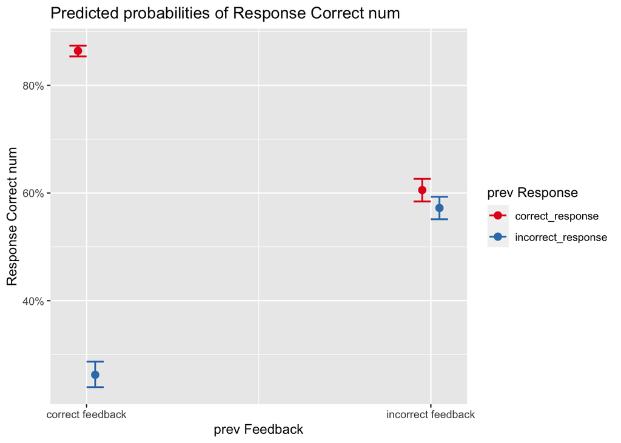

```r
plot_model(mod6.6, type = "pred", terms = c("prevFeedback", "prevResponse"))
```

### Beginning to deal with random effects

```r
minfo[["mod7"]] <- c(fixed="tot_trial_z, PrevRT, phase, phase*prevFeed, prevFeed*prevResp", l2="Intercept + Prev_response/Subject")
mod7 <- glmer(ResponseCorrect_num ~ total_trial_z + prevRT_log + task_phase*prevFeedback*prevResponse + (1  + prevResponse|subject), data = df, family = binomial, control = glmerControl(optimizer = "bobyqa"))
AIC(mod6.5, mod7)
```

```
##        df      AIC
## mod6.5 12 29796.53
## mod7   13 28593.04
```

```r
summary(mod7)
```

```
## Generalized linear mixed model fit by maximum likelihood (Laplace
##   Approximation) [glmerMod]
##  Family: binomial  ( logit )
## Formula: ResponseCorrect_num ~ total_trial_z + prevRT_log + task_phase *
##     prevFeedback * prevResponse + (1 + prevResponse | subject)
##    Data: df
## Control: glmerControl(optimizer = "bobyqa")
##
##      AIC      BIC   logLik deviance df.resid
##  28593.0  28699.7 -14283.5  28567.0    27103
##
## Scaled residuals:
##     Min      1Q  Median      3Q     Max
## -6.4766 -0.7287  0.3215  0.6499  4.8026
##
## Random effects:
##  Groups  Name                           Variance Std.Dev. Corr
##  subject (Intercept)                    0.5746   0.7581
##          prevResponseincorrect_response 1.4450   1.2021   -0.97
## Number of obs: 27116, groups:  subject, 137
##
## Fixed effects:
##                                                                                   Estimate
## (Intercept)                                                                       1.445372
## total_trial_z                                                                    -0.001046
## prevRT_log                                                                        0.098185
## task_phaseReversal                                                               -0.467678
## prevFeedbackincorrect_feedback                                                   -1.699615
## prevResponseincorrect_response                                                   -3.477355
## task_phaseReversal:prevFeedbackincorrect_feedback                                 0.423643
## task_phaseReversal:prevResponseincorrect_response                                 0.543910
## prevFeedbackincorrect_feedback:prevResponseincorrect_response                     3.375429
## task_phaseReversal:prevFeedbackincorrect_feedback:prevResponseincorrect_response -0.844047
##                                                                                  Std. Error
## (Intercept)                                                                        0.167206
## total_trial_z                                                                      0.014985
## prevRT_log                                                                         0.025107
## task_phaseReversal                                                                 0.052592
## prevFeedbackincorrect_feedback                                                     0.056898
## prevResponseincorrect_response                                                     0.131650
```

[output cut: 36 more lines]

```
## task_phaseReversal:prevFeedbackincorrect_feedback:prevResponseincorrect_response ***
## ---
## Signif. codes:  0 '***' 0.001 '**' 0.01 '*' 0.05 '.' 0.1 ' ' 1
##
## Correlation of Fixed Effects:
##             (Intr) ttl_t_ prvRT_ tsk_pR prvFd_ prvRs_ ts_R:F_ t_R:R_ pF_:R_
## total_trl_z -0.124
## prevRT_log  -0.890  0.153
## tsk_phsRvrs -0.210 -0.078  0.040
## prvFdbcknc_ -0.169  0.006  0.003  0.511
## prvRspnsnc_ -0.358  0.000 -0.008  0.220  0.212
## tsk_phsR:F_  0.126 -0.003 -0.011 -0.655 -0.704 -0.147
## tsk_phsR:R_  0.083 -0.001  0.001 -0.481 -0.248 -0.465  0.318
## prvFdbc_:R_  0.089 -0.005  0.008 -0.294 -0.576 -0.517  0.405   0.619
## tsk_R:F_:R_ -0.072  0.005  0.004  0.389  0.419  0.377 -0.595  -0.810 -0.733
```

```r
car::vif(mod7)
```

```
##                        total_trial_z                           prevRT_log
##                             1.046751                             1.031506
##                           task_phase                         prevFeedback
##                             3.174374                             3.164982
##                         prevResponse              task_phase:prevFeedback
##                             1.508653                             5.757401
##              task_phase:prevResponse            prevFeedback:prevResponse
##                             6.183620                             3.931089
## task_phase:prevFeedback:prevResponse
##                             9.137833
```

### Playing around some more with Prev_response effect

clearly a large effect of prev_resp. in a 3-way interaction of task, prev_feedback, and prev_response to see what happened. Seeing some significant collinearity but wondering if something on the random effects side might help things out.

```r
minfo[["mod7.1"]] <- c(fixed="total_trial_z, PrevRT, task phase, previous response*previous feedback", l2="Intercept + Prev_response/Subject; intercept+prevResponse/subject:task_phase")
mod7.1 <- glmer(ResponseCorrect_num ~ total_trial_z + prevRT_log + task_phase*prevFeedback*prevResponse + (1  + prevResponse|subject/task_phase), data = df, family = binomial, control = glmerControl(optimizer = "bobyqa"))

minfo[["mod7.2"]] <- c(fixed="total_trial_z, PrevRT, task phase, prevFeedback*prevResponse*task_phase", l2="Intercept + Prev_response/subject; intercept, prevResponse /subject:task_phase")
mod7.2 <- glmer(ResponseCorrect_num ~ total_trial_z + prevRT_log + task_phase + prevFeedback*prevResponse*task_phase + (1 + prevResponse |subject) + (0 + prevResponse|subject:task_phase), data = df, family = binomial, control = glmerControl(optimizer = "bobyqa"))

dependlab::render_flex_aictab(minfo=minfo, mod6, mod6.1, mod6.2, mod6.3, mod6.4, mod6.6, mod7, mod7.1, mod7.2) %>% autofit()
```

| model | fixed | l2 | logLik | AIC | 𝚫AIC | df | weight |
| --- | --- | --- | --- | --- | --- | --- | --- |
| mod6.2 | tot_trial_z, PrevRT, RT, phase*prevFeed, prevResp | Intercept/Subject | -15,894.71 | 31,807.42 | 3,242.5831170893471 | 9 | 0.0 |
| mod6.3 | tot_trial_z, PrevRT, RT, phase*prevResp + prevFeed | Intercept/Subject | -15,899.82 | 31,817.63 | 3,252.7936812861990 | 9 | 0.0 |
| mod6.4 | tot_trial_z, PrevRT, RT, phase, phase*prevFeed, prevFeed*prevResp | Intercept/Subject | -14,907.53 | 29,835.05 | 1,270.2119597484161 | 10 | 0.0 |
| mod6.5 | tot_trial_z, PrevRT, RT, phase, phase*prevFeed, prevFeed*prevResp | Intercept/Subject |  |  |  |  |  |
| mod6.6 | tot_trial_z, PrevRT, phase, phase*prevFeed, prevFeed*prevResp | Intercept/Subject | -14,907.35 | 29,834.69 | 1,269.8530309174203 | 10 | 0.0 |
| mod7 | tot_trial_z, PrevRT, phase, phase*prevFeed, prevFeed*prevResp | Intercept + Prev_response/Subject | -14,283.52 | 28,593.04 | 28.1981099852710 | 13 | 0.0 |
| mod7.1 | total_trial_z, PrevRT, task phase, previous response*previous feedback | Intercept + Prev_response/Subject; intercept+prevResponse/subject:task_phase | -14,266.42 | 28,564.84 | 0.0000007844428 | 16 | 0.5 |
| mod7.2 | total_trial_z, PrevRT, task phase, prevFeedback*prevResponse*task_phase | Intercept + Prev_response/subject; intercept, prevResponse /subject:task_phase | -14,266.42 | 28,564.84 | 0.0000000000000 | 16 | 0.5 |

```r
car::vif(mod7.2)
```

```
##                        total_trial_z                           prevRT_log
##                             1.036318                             1.028397
##                           task_phase                         prevFeedback
##                             2.237829                             3.202234
##                         prevResponse            prevFeedback:prevResponse
##                             1.530309                             3.927214
##              task_phase:prevFeedback              task_phase:prevResponse
##                             4.704196                             4.590496
## task_phase:prevFeedback:prevResponse
##                             7.440304
```

### PrevFeedback effect

```r
minfo[["mod7.3"]] <- c(fixed="total_trial_z, PrevRT, task phase,  prevFeedback*task_phase, prevFeedback*prevResponse", l2="Intercept, Prev_response/Subject; intercept,prevResponse/subject:task_phase")
mod7.3 <- glmer(ResponseCorrect_num ~ total_trial_z + prevRT_log + task_phase + prevFeedback*prevResponse*task_phase + (1 + prevFeedback |subject) + (0 + prevResponse|subject:task_phase), data = df, family = binomial, control = glmerControl(optimizer = "bobyqa"))

# minfo[["mod7.4"]] <- c(fixed="total_trial_z, PrevRT, task phase,  prevFeedback*task_phase, prevFeedback*prevResponse", l2="Intercept, Prev_response/Subject; intercept,prevResponse/subject:task_phase")
# mod7.4 <- glmer(ResponseCorrect_num ~ total_trial_z + prevRT_log + task_phase + prevFeedback*prevResponse*task_phase + (0 + prevResponse + prevFeedback|subject/task_phase), data = df, family = binomial, control = glmerControl(optimizer = "bobyqa")) #Singular

# minfo[["mod7.5"]] <- c(fixed="total_trial_z, PrevRT, task phase, prevFeedback*task_phase, prevFeedback*prevResponse", l2="Intercept + Prev_response/Subject; intercept,prevResponse/subject:task_phase")
# mod7.5 <- glmer(ResponseCorrect_num ~ total_trial_z + prevRT_log + task_phase + prevResponse*task_phase + prevFeedback*task_phase + prevFeedback*prevResponse + (0 + prevResponse + prevFeedback |subject:task_phase), data = df, family = binomial, control = glmerControl(optimizer = "bobyqa")) #Singular

minfo[["mod7.6"]] <- c(fixed="total_trial_z, PrevRT, task phase,  prevFeedback*task_phase, prevFeedback*prevResponse", l2="Intercept + Prev_response + prevRT + task_phase/Subject")
mod7.6 <- glmer(ResponseCorrect_num ~ total_trial_z + prevRT_log + task_phase + prevFeedback*prevResponse*task_phase + (0 + prevResponse + prevRT_log |subject:task_phase), data = df, family = binomial, control = glmerControl(optimizer = "bobyqa"))
minfo[["mod7.7"]] <- c(fixed="total_trial_z, PrevRT, task phase,  prevFeedback*task_phase, prevFeedback*prevResponse", l2="Intercept + Prev_response + prevRT + task_phase/Subject")
mod7.7 <- glmer(ResponseCorrect_num ~ total_trial_z + prevRT_log + task_phase + prevFeedback*task_phase + prevFeedback*prevResponse + (1 + prevResponse |subject) + (1 |subject:task_phase) , data = df, family = binomial, control = glmerControl(optimizer = "bobyqa"))

# minfo[["mod7.8"]] <- c(fixed="total_trial_z, PrevRT, phase,  prevFeed*phase, prevFeed*prevResponse", l2="Intercept + Prev_response + prevRT /Subject, Subject/phase")
# mod7.8 <- glmer(ResponseCorrect_num ~ total_trial_z + prevRT_log + task_phase + prevFeedback*task_phase + prevFeedback*prevResponse + (1 + task_phase + rt_log |subject/task_phase) , data = df, family = binomial, control = glmerControl(optimizer = "bobyqa")) #Singular fit

# minfo[["mod7.9"]] <- c(fixed="total_trial_z, PrevRT, task phase,  prevFeed*task_phase, prevFeed*prevResponse", l2="Intercept + Prev_response + prevRT + task_phase/Subject")
# mod7.9 <- glmer(ResponseCorrect_num ~ total_trial_z + prevRT_log + task_phase + prevFeedback*task_phase + prevFeedback*prevResponse + (0 + task_phase + rt_log |subject) + (1 |subject:prevResponse) , data = df, family = binomial, control = glmerControl(optimizer = "bobyqa"))

dependlab::render_flex_aictab(minfo=minfo, mod0, mod1, mod1.1, mod2, mod2.1, mod3, mod4, mod5, mod6, mod6.1, mod6.2, mod6.3, mod7, mod7.1, mod7.3, mod7.6, mod7.7) %>% autofit()
```

| model | fixed | l2 | logLik | AIC | 𝚫AIC | df | weight |
| --- | --- | --- | --- | --- | --- | --- | --- |
| mod6.2 | tot_trial_z, PrevRT, RT, phase*prevFeed, prevResp | Intercept/Subject | -15,894.71 | 31,807.42 | 3,242.58312 | 9 | 0 |
| mod6.3 | tot_trial_z, PrevRT, RT, phase*prevResp + prevFeed | Intercept/Subject | -15,899.82 | 31,817.63 | 3,252.79368 | 9 | 0 |
| mod6.4 | tot_trial_z, PrevRT, RT, phase, phase*prevFeed, prevFeed*prevResp | Intercept/Subject |  |  |  |  |  |
| mod6.5 | tot_trial_z, PrevRT, RT, phase, phase*prevFeed, prevFeed*prevResp | Intercept/Subject |  |  |  |  |  |
| mod6.6 | tot_trial_z, PrevRT, phase, phase*prevFeed, prevFeed*prevResp | Intercept/Subject |  |  |  |  |  |
| mod7 | tot_trial_z, PrevRT, phase, phase*prevFeed, prevFeed*prevResp | Intercept + Prev_response/Subject | -14,283.52 | 28,593.04 | 28.19811 | 13 | 0 |
| mod7.1 | total_trial_z, PrevRT, task phase, previous response*previous feedback | Intercept + Prev_response/Subject; intercept+prevResponse/subject:task_phase | -14,266.42 | 28,564.84 | 0.00000 | 16 | 1 |
| mod7.2 | total_trial_z, PrevRT, task phase, prevFeedback*prevResponse*task_phase | Intercept + Prev_response/subject; intercept, prevResponse /subject:task_phase |  |  |  |  |  |
| mod7.3 | total_trial_z, PrevRT, task phase, prevFeedback*task_phase, prevFeedback*prevResponse | Intercept, Prev_response/Subject; intercept,prevResponse/subject:task_phase | -14,348.91 | 28,729.82 | 164.98193 | 16 | 0 |
| mod7.6 | total_trial_z, PrevRT, task phase, prevFeedback*task_phase, prevFeedback*prevResponse | Intercept + Prev_response + prevRT + task_phase/Subject | -14,349.20 | 28,730.41 | 165.56684 | 16 | 0 |
| mod7.7 | total_trial_z, PrevRT, task phase, prevFeedback*task_phase, prevFeedback*prevResponse | Intercept + Prev_response + prevRT + task_phase/Subject | -14,287.66 | 28,599.32 | 34.47843 | 12 | 0 |

```r
# mod_matrix <- as.tibble(ranef(mod7.6), names= "term")
# coefficients <- mod_matrix %>% pivot_wider(
#   names_from = c(term),
#   values_from = c(condsd, condval))
#
# coefficients <- coefficients %>% mutate(subject = grp)
#
# test <- inner_join(coef_StaySwitch_only, coef_cond_only)
#
# coeffs_all <- inner_join(coeffs_all, test)
#
#  with_coefs <- left_join(coefficients, df, by =
#             "subject")
#
# save(with_coefs, file = "~/github_repos/ReversalTask/Data/df_with_coefficients.RData")
```